# Meteo Radar Database Content and Guidelines

Johannes De Groeve

09/01/2020

# Table of Contents

- Meteo Radar
- 1. The Database
  - 1.1. SCHEMAS
  - 1.2. TABLES
  - 1.3. VIEWS
- 2. Tutorials
  - 2.1. DATABASE CONNECTION PARAMETERS
  - 2.2. POSTGRESQL
  - 2.3. R

# Meteo Radar

This document should be considered as a readme to familiarize with the vertical profile (vp) postgresql database content. This platform stores vertical profiles, calculated with the bioRad algorithm (ref) and stored in the file format hdf5, in a classic relational database. The rational behind this database is to provide a fast service to calculate derived measures from the vertical profiles. Because vertical profiles often need to be accessed in bulk, the current storage approach (hierarchical file system) does not allow quick processing. With a relational database processing of vertical profiles has been proven to be much more efficient. Below we first discuss the content of the database (schemas, tables), followed by practical examples on the usage in PostgreSQL and R.

## 1. The Database

The database consists out of several tables that are linked (related) to each other by matching fields (keys). Tables are stored in schemas. Below we discuss first the different schemas, then the main tables and finally the views that make this database.

### 1.1. SCHEMAS

A database is generally organised in different schemas. In this database we differentiate schemas based on their specific purpose. Different schemas may have different access properties and priviliges. We distinguish six different schemas (Figure 1; main, lu_tables, temp, tools, public and mayday) and discuss them in order of relevance for the user.

[figure not shown]

**Figure 1.** Screenshot of schemas in the postgresql database

#### 1.1.1. main

The schema “main” is where the main tables are stored. The data model of the database will be described in more detail below.

#### 1.1.2. lu_tables

The schema “lu_tables” is where the look up tables (lu_tables) are stored. These tables store the list and the description of codes referenced by other tables in the database.

#### 1.1.3. temp

The schema “temp” is the work environment for any collaborator where tables can be stored temporarily. This folder will be emptied the *first of every month*. It is intended to keep this folder organized, so please use a relevant alias that allows to identify who generated the table (e.g., jdg_tablename).

#### 1.1.4. tools

The schema “tools” will store useful tools and functions developed to facilitate the use of the database. Currently there are no tools yet available, but will be developed on demand.

#### 1.1.5. public

The schema “public” should remain empty. In the public schema you can find a table with a list of projection systems (spatial_ref_sys) as generated by the POSTGIS extension. It also stores all functions available in the postgresql database.

#### 1.1.6. mayday

The schema “mayday” will store error shooting when there is an issue with the database. This is only relevant for the data manager.

### 1.2. TABLES

This part describes the main tables of the database essential for the user. As mentioned important tables are stored in the schema “main”. This schema contains five tables of which two (radar_odim, radar_sensor) are related to the *radar* and three (vp_file, vp_data, vp_settings) to the generated vertical profiles and the associated algorithm that was used.

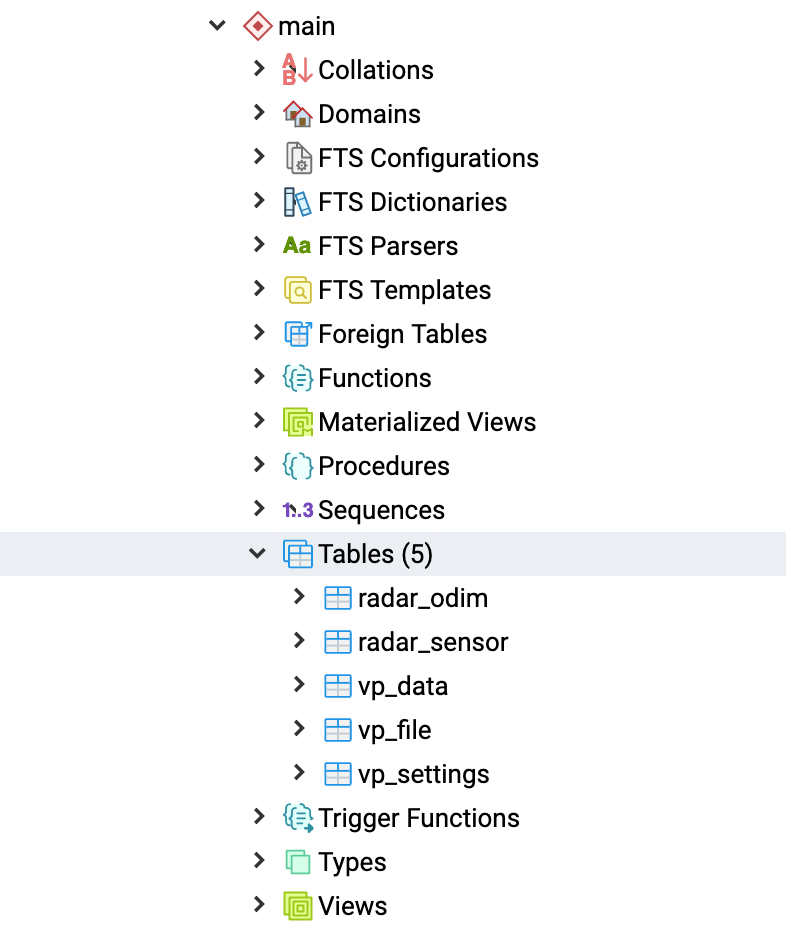

**Figure 2.** Screenshot of tables in the main schema in the postgresql database

#### 1.2.1. radar_odim

The name and place of the radar station, the list is based on several sources, with as main source https://github.com/enram/globam-dmp/blob/master/data/OPERA_RADARS_DB.json’. Following columns are included:

- **radar_odim_id** Unique identifier for the radar station in db.
- **opera_radar_number** Unique identifier as defined in the opera json file.
- **odim_code** OPERA Data Information Model (ODIM) standard code for the radar (first two letters represent the country and the last three letters the location).
- **wmo_code** World Meteorological Organization (WMO) code.
- **location_name** Full name of the location of the radar.
- **country_code** Official two letter abbreviation of the country where the radar is located.
- **status** Whether the radar is active (TRUE) or inactive (FALSE) as from 2019-10-23.
- **vp_in_db** Number of vps imported in the database for that radar location.

Table 1. extract radar_odim table

| radar_odim_id | opera_radar_number | odim_code | wmo_code | location_name | country_code | status | vp_in_db |
| --- | --- | --- | --- | --- | --- | --- | --- |
| 6 | 1128 | bezav | 6451 | Zaventem | be | TRUE | 131159 |
| 7 | 1129 | bewid | 6477 | Wideumont | be | TRUE | 133944 |
| 8 | 1356 | bejab | 6410 | Jabbeke | be | TRUE | 126811 |
| 137 | 1206 | nldbl | 6260 | De Bilt | nl | FALSE | 157591 |
| 138 | 1207 | nldhl | 6234 | Den Helder | nl | TRUE | 248995 |
| 139 | 1385 | nlhrw | 6356 | Herwijnen | nl | TRUE | 94985 |

#### 1.2.2. radar_sensor

Sensor specific information.

- **radar_sensor_id** unique identifier for the settings (i.e., position, height,…) at a radar location.
  - **radar_odim_id** corresponding radar location.
  - **latitude** Latitude position of the radar antenna (degrees), normalized to the WGS-84 reference ellipsoid and datum. Fractions of a degree are given in decimal notation.
  - **longitude** Longitude position of the radar antenna (degrees), normalized to the WGS-84 reference ellipsoid and datum. Fractions of a degree are given in decimal notation.
  - **geom** Geometry based on the longitude and latitude of the radar antenna.
  - **height** Height of the centre of the antenna in meters above sea level.
  - **levels** Number of points in the profile.
  - **“interval”** Vertical distance (m) between height intervals, or 0.0 if variable..
  - **max_height** Maximum height in meters above mean sea level.
  - **min_height** Minimum height in meters above mean sea level.
  - **beam_width** The radar’s half-power beamwidth (degrees).

Table 2. extract radar_sensor table

| radar_sensor_id | radar_odim_id | latitude | longitude | height | levels | interval | max_height | min_height | beam_width | geom |
| --- | --- | --- | --- | --- | --- | --- | --- | --- | --- | --- |
| 1 | 8 | 51.19170 | 3.06420 | 50.0 | 25 | 200 | 5000 | 0 | 1.000 | 0101000020E6100000C139234A7B830840545227A089984940 |
| 2 | 7 | 49.91430 | 5.50560 | 590.0 | 25 | 200 | 5000 | 0 | 1.000 | 0101000020E61000002F6EA301BC051640CC5D4BC807F54840 |
| 3 | 6 | 50.90550 | 4.45500 | 90.0 | 25 | 200 | 5000 | 0 | 1.065 | 0101000020E6100000FBFFFF7FEBD1114004000060E7734940 |
| 5 | 138 | 52.95279 | 4.79061 | 51.0 | 25 | 200 | 5000 | 0 | 0.905 | 0101000020E6100000010000A095291340FCFFFFFFF4794A40 |
| 6 | 139 | 51.83690 | 5.13810 | 27.7 | 25 | 200 | 5000 | 0 | 0.905 | 0101000020E6100000FBFFFF1F6A8D1440FBFFFF7F1FEB4940 |
| 23 | 137 | 52.10168 | 5.17834 | 44.0 | 25 | 200 | 5000 | 0 | 0.905 | 0101000020E6100000020000C09EB61440FBFFFFDF030D4A40 |
| 24 | 138 | 52.95334 | 4.79997 | 51.0 | 25 | 200 | 5000 | 0 | 0.905 | 0101000020E6100000040000602B33134004000000077A4A40 |

#### 1.2.3. vp_file

Vertical profile file names and related timestamps generated by pvol2bird.

- **vp_file_id** unique identifier of the vpfile.
  - **vp_time** the actual timestamp of the vpfile.
  - **start_time** Start time of the data in the vp file.
  - **end_time** End time of the data in the vp file.
  - **radar_sensor_id** link to the radar sensor from which the raw radar data originates to generate the vp file.
  - **vp_settings_id** link to the settings of the bird2vol algorithm.
  - **vp_file_original_name** the original name of the vp_file.

Table 3. extract vp_file table

| vp_file_id | vp_time | start_time | end_time | radar_sensor_id | vp_settings_id | vp_file_original_name |
| --- | --- | --- | --- | --- | --- | --- |
| 801624 | 2008-02-15 00:00:09 | 2008-02-15 00:00:09 | 2008-02-15 00:04:06 | 23 | 15 | nldbl_vp_20080215t0000_nl50_v0-3-20 |
| 801625 | 2008-02-15 00:05:10 | 2008-02-15 00:05:10 | 2008-02-15 00:09:07 | 23 | 15 | nldbl_vp_20080215t0005_nl50_v0-3-20 |
| 801626 | 2008-02-15 00:10:10 | 2008-02-15 00:10:10 | 2008-02-15 00:14:07 | 23 | 15 | nldbl_vp_20080215t0010_nl50_v0-3-20 |
| 801627 | 2008-02-15 00:15:09 | 2008-02-15 00:15:09 | 2008-02-15 00:19:06 | 23 | 15 | nldbl_vp_20080215t0015_nl50_v0-3-20 |
| 801628 | 2008-02-15 00:20:09 | 2008-02-15 00:20:09 | 2008-02-15 00:24:07 | 23 | 15 | nldbl_vp_20080215t0020_nl50_v0-3-20 |

#### 1.2.4. vp_data

Data generated by pvol2bird.

- **vp_data_id** unique identifier for each data point.
  - **vp_file_id** vp file unique id.
  - **ff** Mean horizontal wind velocity [m/s].
  - **dbz** Bird reflectivity factor.
  - **dens** Volume bird density [birds/km^3].
  - **u** Speed component west to east [m/s].
  - **v** Speed component north to south [m/s].
  - **gap** Angular data gap detected [1=yes, 0=no].
  - **w** Vertical velocity [positive upwards, m/s].
  - **n_dbz** Number of points bird density estimate (dbz,eta,dens).
  - **dd** Horizontal ground speed direction of animal movement - derived from radial velocity [degrees, clockwise from north].
  - **n** number of points VVP bird velocity analysis (u,v,w,ff,dd).
  - **dbzh** Logged horizontally-polarized (corrected) reflectivity factor.
  - **hght** Height above mean sea level [m].
  - **n_dbz_all** Number of points total reflectivity estimate.
  - **eta** Bird reflectivity [cm<sup>2/km</sup>3] - linear reflectivity-derived estimate.
  - **sd_vvp** VVP radial velocity standard deviation [m/s] derived from radial velocity. VVP = Volume Velocitty Profiling.
  - **n_all** Number of points VVP st.dev estimate.

Table 4. extract vp_data table

| vp_data_id | vp_file_id | ff | dbz | dens | u | v | gap | w | n_dbz | dd | n | dbzh | hght | n_dbz_all | eta | sd_vvp | n_all |
| --- | --- | --- | --- | --- | --- | --- | --- | --- | --- | --- | --- | --- | --- | --- | --- | --- | --- |
| 1 | 1 | NA | -2.665587 | 0.0000000 | NA | NA | 1 | NA | 221 | NA | 221 | 32.827785 | 0 | 2987 | 190.3085632 | 1.510348 | 2266 |
| 2 | 1 | 2.0466518 | -6.440475 | 0.0000000 | 2.0361571 | -0.2069970 | 0 | -26.3827629 | 6282 | 95.80479 | 1233 | 12.219991 | 200 | 11643 | 79.7938690 | 1.908532 | 3436 |
| 3 | 1 | 1.2886029 | -13.470701 | 0.0000000 | 1.2136070 | 0.4331923 | 0 | 1.2828500 | 8992 | 70.35617 | 750 | -6.749590 | 400 | 10853 | 15.8105478 | 1.450169 | 1267 |
| 4 | 1 | 1.4490567 | -12.378657 | 0.0000000 | 1.2988645 | 0.6424302 | 0 | 1.7819297 | 5694 | 63.68258 | 926 | -8.898586 | 600 | 6248 | 20.3306503 | 1.372619 | 1092 |
| 5 | 1 | 1.4338948 | -17.031540 | 0.0000000 | 1.2802771 | 0.6457124 | 0 | 1.2697157 | 6626 | 63.23574 | 798 | -14.034529 | 800 | 7183 | 6.9640675 | 1.353595 | 970 |
| 6 | 1 | 1.3397423 | -15.407846 | 0.0000000 | 1.1890410 | 0.6173257 | 0 | 1.2282902 | 3837 | 62.56259 | 591 | -11.261450 | 1000 | 4373 | 10.1212091 | 1.360535 | 764 |
| 7 | 1 | 1.2888376 | -18.655355 | 0.0000000 | 1.2530352 | 0.3016704 | 0 | 1.5499194 | 5319 | 76.46355 | 599 | -17.575275 | 1200 | 5830 | 4.7916093 | 1.336512 | 694 |
| 8 | 1 | 1.1525770 | -16.724100 | 0.0000000 | 1.0234944 | 0.5299934 | 0 | 1.8060862 | 4944 | 62.62364 | 700 | -16.694998 | 1400 | 5010 | 7.4749284 | 1.561953 | 707 |
| 9 | 1 | 1.2763439 | -21.250284 | 0.0000000 | 1.0729450 | 0.6912618 | 0 | 0.9353353 | 4037 | 57.20770 | 358 | -21.250284 | 1600 | 4037 | 2.6362624 | 1.308315 | 358 |
| 10 | 1 | 0.7461067 | -21.632780 | 0.0000000 | 0.5796151 | 0.4698100 | 0 | 2.1995497 | 3880 | 50.97332 | 222 | -21.632780 | 1800 | 3880 | 2.4140100 | 1.969012 | 222 |
| 11 | 1 | 1.3995765 | -17.853085 | 0.0000000 | 1.2167262 | 0.6916589 | 0 | 1.5237079 | 3544 | 60.38355 | 283 | -17.853085 | 2000 | 3544 | 5.7637963 | 1.357807 | 283 |
| 12 | 1 | 1.2260514 | -22.711887 | 0.0000000 | 1.1676921 | 0.3737613 | 0 | 0.5920327 | 3160 | 72.25088 | 288 | -21.955233 | 2200 | 3257 | 1.8829044 | 1.289385 | 385 |
| 13 | 1 | 1.7780881 | -25.798357 | 0.0000000 | 1.3735855 | 1.1290971 | 0 | 0.3274499 | 3117 | 50.57955 | 305 | -25.798357 | 2400 | 3117 | 0.9250845 | 1.016889 | 305 |
| 14 | 1 | 1.8478857 | -24.089685 | 0.0000000 | 1.6486676 | 0.8346119 | 0 | 0.0771148 | 2772 | 63.14991 | 281 | -24.089685 | 2600 | 2772 | 1.3710345 | 1.107595 | 281 |
| 15 | 1 | 1.7434212 | -18.880602 | 0.0000000 | 1.5108440 | 0.8699816 | 0 | -0.1664822 | 2405 | 60.06559 | 277 | -18.880602 | 2800 | 2405 | 4.5494280 | 1.170359 | 277 |
| 16 | 1 | NA | -23.937901 | 0.0000000 | NA | NA | 1 | NA | 1740 | NA | 132 | -23.937901 | 3000 | 1740 | 1.4197994 | NA | 132 |
| 17 | 1 | 1.3277136 | -28.039154 | 0.0000000 | 1.1318909 | 0.6940075 | 0 | -1.2614512 | 2101 | 58.48587 | 81 | -28.039154 | 3200 | 2101 | 0.5522065 | 1.141870 | 81 |
| 18 | 1 | NA | -24.529730 | 0.0000000 | NA | NA | 1 | NA | 1744 | NA | 62 | -24.529730 | 3400 | 1744 | 1.2389222 | NA | 62 |
| 19 | 1 | NA | -28.367353 | 0.0000000 | NA | NA | 1 | NA | 1772 | NA | 66 | -28.367353 | 3600 | 1772 | 0.5120139 | NA | 66 |
| 20 | 1 | 1.1939499 | -28.269497 | 0.0476074 | 1.1675627 | 0.2496273 | 0 | -1.1631634 | 1789 | 77.93174 | 45 | -28.269497 | 3800 | 1789 | 0.5236816 | 2.205113 | 45 |
| 21 | 1 | NA | -22.713808 | 0.0000000 | NA | NA | 1 | NA | 1067 | NA | 29 | -22.713808 | 4000 | 1067 | 1.8820720 | NA | 29 |
| 22 | 1 | NA | -34.369541 | 0.0000000 | NA | NA | 1 | NA | 1077 | NA | 5 | -34.369541 | 4200 | 1077 | 0.1285473 | NA | 5 |
| 23 | 1 | NA | -Inf | 0.0000000 | NA | NA | 1 | NA | 720 | NA | 0 | -Inf | 4400 | 720 | 0.0000000 | NA | 0 |
| 24 | 1 | NA | -38.573326 | 0.0000000 | NA | NA | 1 | NA | 720 | NA | 0 | -38.573326 | 4600 | 720 | 0.0488298 | NA | 0 |
| 25 | 1 | NA | -Inf | 0.0000000 | NA | NA | 1 | NA | 1080 | NA | 0 | -Inf | 4800 | 1080 | 0.0000000 | NA | 0 |

#### 1.2.5. vp_settings

Settings of the pvol2bird algorithm as stored in the hdf5 files.

- **vp_settings_id** unique identifier for settings.
  - **version** h5 version.
  - **task_args** original task_args string.
  - **vcp** Volume Coverage Pattern.
  - **comment** if comments are added.
  - **azimmax** the maximum azimuth [degrees] used for constructing the bird density profile.
  - **azimmin** the minimum azimuth [degrees] used for constructing the bird density profile.
  - **nlayers** the number of layers in an altitude profile.
  - **rangemax** Maximum range at which data is used when generating bird density profile (km).
  - **rangemin** Minimum range at which data is used when generating bird density profile (km).
  - **elevmax** the maximum scan elevation [degrees] used for constructing the bird density profile.
  - **elevmin** the minimum scan elevation [degrees] used for constructing the bird density profile.
  - **radarwavelength** the wavelength [cm] of the radar.
  - **usecluttermap** whether a static clutter map is used.
  - **cluttermap** Filename of clutter map.
  - **fitvrad** Whether or not to fit a model to the observed vrad.
  - **exportbirdprofileasjsonvar** Whether to export bird profile as JSON.
  - **minnyquist** Minimum Nyquist velocity, scans with Nyquist velocity below this threshold are ignored.
  - **maxnyquistdealias** Scans with Nyquist velocity higher than this threshold are not dealiased.
  - **birdradarcrosssection** Bird radar cross section [cm^2].
  - **stddevminbird** VVP Radial velocity standard deviation threshold.
  - **celletamin** Minimum mean reflectivity [cm<sup>2/km</sup>3] for cells containing birds.
  - **etamax** Maximum reflectivity [cm<sup>2/km</sup>3] for gates containing birds.
  - **dbztype** reflectivity quantity to use, one of DBZH, DBZV, TH, TV.
  - **requirevrad** for a range gate to contribute it should have a valid radial velocity.
  - **dealiasvrad** “TRUE” if data has been dealiased, “FALSE” if not.
  - **dualpol** whether to use dual-pol moments for filtering meteorological echoes.
  - **singlepol** whether to use single-pol moments for filtering meteorological echoes.
  - **rhohvthresmin** correlation coefficients higher than this threshold will be classified as precipitation.

[figure not shown]

**Figure 3.** Meteo Radar Data Model

### 1.3. VIEWS

A view is the result set of a stored query on the data. This database includes seven views which are stored in the **main** schema, of which two give a summary of the vp files at different levels of detail, four calculate integrated profiles binned over different time intervals and one reconstructs the original file names as stored in the original S3-bucket.

#### 1.3.1. Integrated profile

Integrated profiles were calculated using the same algorithms as available in bioRad. Some integrated profile variables were not included because of mismatched between original and postgresql calculation. Four views are available, binned over different temporal intervals:

- **integrate_profile**
  - **integrate_profile15min**
  - **integrate_profile30min**
  - **integrate_profile60min**

#### 1.3.2. Summaries vp files

Two views provide a summary of the vertical profiles per odim code at different levels.

- **vp_dayodyrmd** Number of files for each day (columns) per odim code-year-month (rows).
  - **vp_month_od** Number of files for each month (columns) per odim code (rows).

#### 1.3.3. Source files

- **source_files** Original pvol and vp path names as stored in the S3-bucket.

## 2. Tutorials

### 2.1. DATABASE CONNECTION PARAMETERS

To access the database, whether it is from the psql console, through a database graphical user interface (e.g., pgadmin, dbeaver) or through another client software (e.g., R, matlab, qgis), connection always requires a minimum set of parameters:

- **host** ibedb.science.uva.nl
  - **port** 5432
  - **database** meteo_radar
  - **username**
  - **password**

How the arguments are named will depend from the software.

### 2.2. POSTGRESQL

In this section a couple of examples are provided on how to use different SQL statements in this database, including FROM, WHERE, COUNT and JOIN. Next a couple of different solutions are given for the same problems. To conclude examples are given on how to query VIEWS.

#### 2.2.1. FROM

##### Access the main tables in the database.

```sql
SELECT * FROM main.radar_odim;

SELECT * FROM main.radar_sensor;

SELECT * FROM main.vp_file;

SELECT * FROM main.vp_data;

SELECT * FROM main.vp_settings;

SELECT * FROM lu_tables.countries;
```

#### 2.2.2. WHERE

##### Select a single odim from the radar_odim table

```sql
SELECT *
FROM main.radar_odim
WHERE odim_code = 'nldhr';
```

##### Select multiple odim codes from the radar_odim table (IN)

```sql
SELECT *
FROM main.radar_odim
WHERE odim_code in ('nldhr','bewir');
```

##### Select all odim codes except some from the radar_odim table (NOT IN).

```sql
SELECT *
FROM main.radar_odim
WHERE odim_code not in ('nldhr','bewir')
```

##### Select vp_files between two timestamps (BETWEEN AND)

```sql
SELECT *
FROM main.vp_file
WHERE vp_time between '2018-02-15 00:00:00' and '2018-03-15 23:59:59';
```

##### Select vp_files between two timestamps (BETWEEN AND)

```sql
SELECT *
FROM main.vp_file
WHERE vp_time between '2018-02-15 00:00:00' and '2018-03-15 23:59:59';
```

##### Select vp_files for February (EXTRACT)

```sql
SELECT *
FROM main.vp_file
WHERE extract(month FROM vp_time) in (2);
```

```sql
SELECT *
FROM main.vp_file
WHERE extract(hour FROM vp_time) in (18) & extract(month FROM vp_time) in (18);
```

```sql
SELECT *, extract(month FROM vp_time) monthx, extract(month FROM vp_time) timex
FROM main.vp_file
LIMIT 5;
```

##### Shortcut to odim code from the vp_file table (LIKE, LEFT).

The odim code is also stored in the column vp_file_original_name. You can use this field as a shortcut to know the odim code for a radar.

```sql
-- Method 1
SELECT *
FROM main.vp_file
WHERE vp_file_original_name like ('nldhl%');

-- Method 2
SELECT *
FROM main.vp_file
WHERE left(vp_file_original_name,5) in ('nldhl', 'nldbl');
```

#### 2.2.3. COUNT

##### Count how many records are in the radar_odim table (COUNT).

```sql
SELECT count(*) records_total
FROM main.radar_odim
```

```sql
SELECT count(*) records_with_odim_code
FROM main.radar_odim
WHERE odim_code is not null
```

```sql
SELECT count(*) records_without_odim_code
FROM main.radar_odim
WHERE odim_code is null
```

##### Count proportion of records that have an odim code in the radar_odim table (COUNT).

```sql
-- Because count returns standard an integer you need to specify that it needs to be a double precision.
-- Otherwise 0 is returned when calculating the propotion.
SELECT count(*)::double precision /(SELECT count(*) FROM main.radar_odim) proportion
FROM main.radar_odim
WHERE odim_code is not null
```

##### Count how many of the odim codes have data in the db (COUNT).

```sql
SELECT count(*)
FROM main.radar_odim
WHERE vp_in_db != 0;
```

##### Count how many vp files are in the db per month (COUNT).

```sql
SELECT extract(month from start_time) monthx, count(*)
FROM main.vp_file
GROUP BY extract(month from start_time);
```

##### Count how many altitude bins are there in each file (COUNT).

```sql
SELECT count(*), vp_file_id
FROM main.vp_data
GROUP BY vp_file_id;
```

##### Are there differences in number of altitude bins between files (DISTINCT)?

```sql
SELECT DISTINCT count(*)
FROM main.vp_data
GROUP BY vp_file_id;
```

##### Check whether there are radar_odim_ids with changing sensor values (COUNT).

```sql
SELECT count(*), radar_odim_id
FROM main.radar_sensor
GROUP BY radar_odim_id
HAVING count(*) > 1;
```

##### Check which odim_code has changing sensor values (COUNT, JOIN).

```sql
SELECT count(*), odim_code
FROM main.radar_odim JOIN main.radar_sensor USING (radar_odim_id)
GROUP BY odim_code
HAVING count(*) > 1;
```

#### 2.3.4. JOIN

##### plot vp_data including variables stored in different tables (JOIN including most tables)

```sql
SELECT vp_time, start_time, end_time, odim_code, radar_sensor_id, country_code, longitude, latitude, vp_data.*
FROM main.vp_data
JOIN main.vp_file USING (vp_file_id)
JOIN main.radar_sensor USING (radar_sensor_id)
JOIN main.radar_odim USING (radar_odim_id)
WHERE odim_code = 'nldhl';
```

#### 2.3.5. MULTIPLE SOLUTIONS

Often the same questions can be answered with different queries. One approach might be more efficient than another. Here are some examples on different ways to query the same question.

##### Count how many vp files are in the db per odim.

```sql
-- Method 1: with count
SELECT radar_odim_id, count(*)
FROM main.vp_file
JOIN main.radar_sensor USING (radar_sensor_id)
GROUP BY radar_odim_id;

-- Method 3: with count using the vp_file table
SELECT left(vp_file_original_name,5) odim_code, count(*)
FROM main.vp_file
GROUP BY odim_code;

-- Method 2: using the record vp_in_db
SELECT odim_code, vp_in_db
FROM main.radar_odim
WHERE vp_in_db != 0;
```

##### Count how many vp files are in the db for a country.

```sql
-- Method 1: by summing the number of vp_in_db per country code
SELECT country_code, sum(vp_in_db)
FROM main.radar_odim
WHERE vp_in_db != 0
GROUP BY country_code;

-- Method 2: count and join
SELECT country_code, count(*)
FROM main.vp_file
JOIN main.radar_sensor USING (radar_sensor_id)
JOIN main.radar_odim USING (radar_odim_id)
GROUP BY country_code;

-- Method 3: extract the country code from the vp_file_original_name and count
SELECT left(vp_file_original_name,2) country_code, count(*)
FROM main.vp_file
GROUP BY country_code;
```

##### Count how many vp files are in the db per month per odim.

```sql
-- Method 1
SELECT radar_odim_id, extract(month from start_time) monthx, count(*)
FROM main.vp_file
JOIN main.radar_sensor USING (radar_sensor_id)
GROUP BY radar_odim_id, extract(month from start_time);

-- Method 2
SELECT left(vp_file_original_name,5) odim_code, extract(month from start_time) monthx, count(*)
FROM main.vp_file
GROUP BY odim_code, extract(month from start_time);
```

```sql
-- Methods 1
SELECT DISTINCT radar_odim_id FROM
  (
  SELECT count(*), vp_file_id
  FROM main.vp_data
  GROUP BY vp_file_id
  HAVING count(*) <= 20
  ) x
JOIN main.vp_file using (vp_file_id)
JOIN main.radar_sensor USING (radar_sensor_id);

-- Methods 2
SELECT DISTINCT left(vp_file_original_name,5) odim_code, count FROM
  (
  SELECT count(*), vp_file_id
  FROM main.vp_data
  GROUP BY vp_file_id
  HAVING count(*) <= 20
  ) x
JOIN main.vp_file using (vp_file_id);

-- Methods 3
SELECT DISTINCT count(*), left(vp_file_original_name,5) odim_code
FROM main.vp_data JOIN main.vp_file USING (vp_file_id)
GROUP BY vp_file_id, odim_code
HAVING count(*) <= 20
```

#### 2.3.6. VIEWS

```sql
-- Calculate integrated profile
SELECT * FROM main.integrate_profile;

-- Calculate integrated profiles for February
SELECT * FROM main.integrate_profile WHERE extract(month from vp_time) = 2;

-- Calculate integrated profiles from February until May
SELECT * FROM main.integrate_profile WHERE extract(month from vp_time) BETWEEN 2 and 5;

-- Calculate integrated profile only for one odim code
SELECT * FROM main.integrate_profile WHERE odim_code = 'nldhl';
```

### 2.3. R

#### 2.3.1. INSTALL UVARADAR

Download the zip file directly from https://gitlab.com/bartk/uvaradar/-/archive/master/uvaradar-master.zip

```r
# Install uvaRadar with the downloaded file
remotes::install_local('~/Downloads/uvaradar-master.zip')
```

#### 2.3.2. LOAD PACKAGES

```r
# Load packages
library(RPostgreSQL)
library(bioRad)
library(uvaRadar)
```

#### 2.3.3. CONNECT TO THE DATABASE

```r
# Connect to the database
con <- dbConnect("PostgreSQL",
                 dbname="meteo_radar",
                 host="ibedb.science.uva.nl",
                 user='<username>',
                 password= '<password>')
```

#### 2.3.4. INTERACT WITH THE DATABASE

##### Example 1

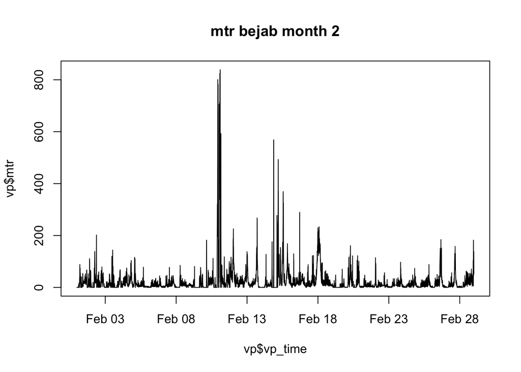

```r
# Query the database (example: mtr of bejab in February)
query <- "SELECT vp_time, odim_code, mtr, extract(month FROM vp_time) monthx
          FROM main.integrate_profile
          WHERE odim_Code in ('bejab') AND
          extract(year FROM vp_time) = 2018 AND
          extract(month FROM vp_time) = 2"
vp <- dbGetQuery(con, query)

# Plot mtr
plot(x=vp$vp_time,
     y=vp$mtr,
     type='l',
     main=paste0('mtr ',unique(vp$odim_code),' month ', unique(vp$monthx)))
```

##### Example 2

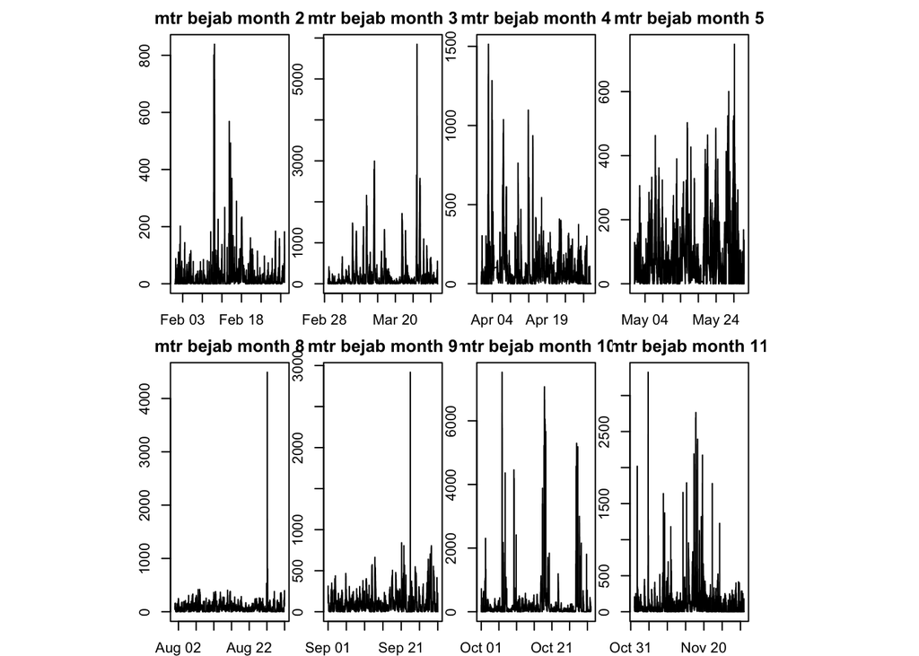

```r
# Plot mtr for all months in 2018
par(mfrow=c(2,6), mar=c(2,1,2,1))
vp_l<-list(data.frame())
mtri<-0
mtrmax<-0
for(i in 1:12){
  # extract mtr for all available months
  query <- paste0("SELECT vp_time, odim_code, mtr, extract(month FROM vp_time) monthx
          FROM main.integrate_profile
          WHERE odim_Code in ('bejab') AND
          extract(year FROM vp_time) = 2018 AND
          extract(month FROM vp_time) = ",i)
  vp <- dbGetQuery(con, query)

  # Plot mtr each month in separate panel
  if(nrow(vp) == 0){
  plot(x=0:1,y=0:1,col='white', xlab = NA, ylab=NA,axes=FALSE)
  } else {
  # plot mtr
  plot(x=vp$vp_time,
       y=vp$mtr,
       type='l',
       main=paste0('mtr ',unique(vp$odim_code),' month ', unique(vp$monthx)),
       xlab=NA, ylab=NA)
  }
  # calculate the maximum mtr value
  if(i == 1){if(nrow(vp)==0){mtrmax <- 0} else {mtrmax <- max(vp$mtr)}}
  if(i != 1){if(nrow(vp)==0){mtri <- 0} else { mtri <- max(vp$mtr)}}

  if(mtri > mtrmax){mtrmax <- mtri}

  vp_l[[i]] <- vp
}
```

##### Example 3

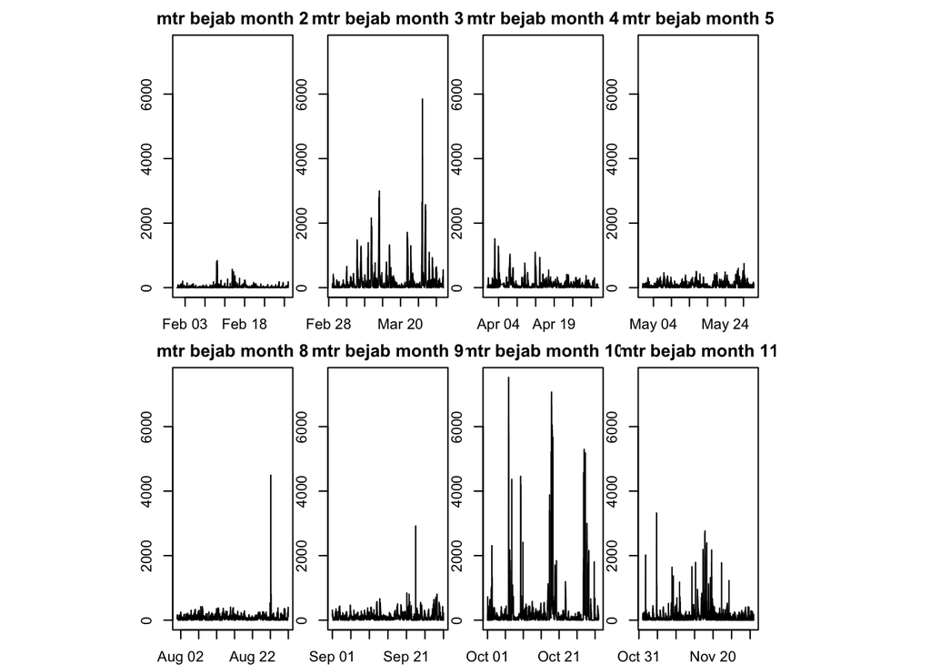

```r
# Plot mtr for all months in 2018 (y-axis limits based on maximum mtr)
par(mfrow=c(2,6), mar=c(2,1,2,1))
for(i in 1:12){
  vp <- vp_l[[i]]

  # Plot mtr each month in separate panel
  if(nrow(vp) == 0){
  plot(x=0:1,y=0:1,col='white', xlab = NA, ylab=NA,axes=FALSE)
  } else {
  # plot mtr
  plot(x=vp$vp_time,
       y=vp$mtr,
       type='l',
       ylim=c(0,mtrmax), # mtrmax calculated calculated in the previous code chunk
       main=paste0('mtr ',unique(vp$odim_code),' month ', unique(vp$monthx)),
       xlab=NA, ylab=NA)
  }
}
```